# Lab 01 - Hello R!

R is the name of the programming language itself and RStudio is a convenient interface.

The goal of this lab is to refresh your knowledge of R and RStudio, which we will be using throughout the course both to learn the statistical methods discussed in the course and to analyze real data and come to informed conclusions.

# Basic Commands

If Rstudio asks to Remove Output, accept it!

In Rstudio, you can run code in your Console (usually the bottom panel), or directly in-line in the document. Similarly, the output can be set to display in-line or in the console. For now, let’s change the settings to output to the console. At the top of this file, click on the gear next to “Knit” and make sure that the option “Chunk Output in Console” is checkmark-ed.

Let’s begin by running the following code. You can run this whole chuck at once by hitting the green triangle on the top-right of the chunk. Or, you can run each line one at a time by clicking anywhere in the first line of code you want to run, then succesively hitting Command+Enter. You will notice that you automatically jump to the following line.

```r
x <- c(1, 3, 5)
x
```

```
## [1] 1 3 5
```

Here, `c()` is a **function**. The name of the function is `c`, short for *concatenate*. `c()` takes any number of inputs, and outputs a *vector* of the inputs. We save the results of the joined numbers into the vector `x` using the operator `<-`. When we type `x`, it gives us back the vector.

Here, we create a new vector called `y`:

```r
y <- c(2, 4, 6)
```

Let’s add the two vectors `x` and `y` together! However, the vectors should both be the same length. We can check this using the `length()` function:

```r
length(x)
```

```
## [1] 3
```

```r
length(y)
```

```
## [1] 3
```

```r
x + y
```

```
## [1]  3  7 11
```

Generally, `R` is pretty good about telling about when the dimensions do not match:

Notice that here, this operation still runs, even though the dimensions do not match!

```r
z <- c(1, 2)
x + z
```

```
## [1] 2 5 6
```

# Lists

We can make a **list** of objects using the function `list()`:

```r
my_ls <- list(x, y)
my_ls
```

```
## [[1]]
## [1] 1 3 5
##
## [[2]]
## [1] 2 4 6
```

Sometimes, it can be helpful to name items in our list. We can do this by giving a name to each item:

```r
my_ls <- list(vec1 = x, vec2 = y)
my_ls
```

```
## $vec1
## [1] 1 3 5
##
## $vec2
## [1] 2 4 6
```

# Matrices

We will often be working with **matrices**. We can create matrices using the `matrix()` function. We will pass in three inputs the data (elements of the matrix), the number of rows, and number of columns.

Note: we do not need to type `data =`, `nrow =`, or `ncol=`, because the default/expected first three inputs for the `matrix()` function are exactly these values. However, it can be useful to explicitly tell `R` what we are passing in.

```r
x <- matrix(data = c(1,2,3,4,5,6), nrow = 2, ncol = 3)
x
```

```
##      [,1] [,2] [,3]
## [1,]    1    3    5
## [2,]    2    4    6
```

Also, notice that `R` creates matrices by filling in columns first. We can specify to fill by rows:

Use the `?matrix()` command to open the help file for the `matrix()` function. In general, typing `?` immediately preceding a function name will open the help file!

```r
matrix(data = c(1,2,3,4,5,6), nrow = 2, ncol = 3, byrow = T)
```

```
##      [,1] [,2] [,3]
## [1,]    1    2    3
## [2,]    4    5    6
```

We can also obtain the square-root or squared-value of each element in a matrix:

```r
sqrt(x)
```

```
##          [,1]     [,2]     [,3]
## [1,] 1.000000 1.732051 2.236068
## [2,] 1.414214 2.000000 2.449490
```

```r
x^2
```

```
##      [,1] [,2] [,3]
## [1,]    1    9   25
## [2,]    4   16   36
```

The `rnorm()` functions generate a vector of normally-distributed random variables. The first argument `n` is the sample size. By default, `rnorm()` generates standard normal random variables (mean 0, sd 1). We can change this by specifying other values:

```r
x <- rnorm(50)
y <- rnorm(50, mean = 1, sd = 0.1)
```

Rather than displaying all the values of `x`, sometimes we just want to see the first few. This can be achieved using the function `head()`:

```r
head(x)
```

[output not shown]

You most likely have different values than me. This is because there is an algorithm that randomly generates values, so your randomly generated values can be different from mine. If we want to reproduce the exact same set every time, we can use the `set.seed()` function. As input, this function takes any integer argument:

```r
set.seed(42)
rnorm(5)
```

```
## [1]  1.3709584 -0.5646982  0.3631284  0.6328626  0.4042683
```

We can use the functions `mean()`, `var()`, and `sd()` to compute the mean, variance, and standard deviation of a vector of numbers.

```r
set.seed(3)
y <- rnorm(100)
mean(y)
```

```
## [1] 0.01103557
```

```r
var(y)
```

```
## [1] 0.7328675
```

```r
sd(y)
```

```
## [1] 0.8560768
```

```r
sqrt(sd(y))
```

```
## [1] 0.9252442
```

# Plotting

This course will mostly use the tidyverse and ggplot for coding and plotting. However, base R code and plots will be accepted. The following code creates a data frame called `df`, which is then used to generate a scatterplot:

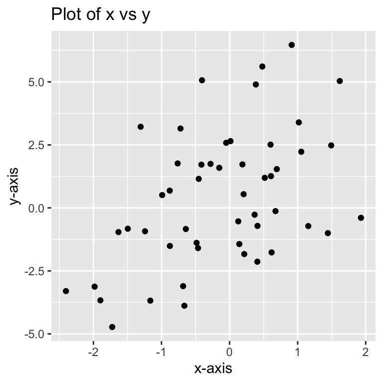

```r
x <- rnorm(50)
y <- x + rnorm(50, 0.2, 2)
df <- data.frame(x = x, y = y)

df %>%
 ggplot(., aes(x = x, y = y))+
 geom_point() +
 labs(x = "x-axis", y = "y-axis") +
 ggtitle("Plot of x vs y")
```

We can also color the points by a variable:

```r
df2 <- df %>%
 mutate(pos_sum = x + y > 0)
df2 %>%
 ggplot(., aes(x = x, y = y, col = pos_sum))+
 geom_point() +
 labs(x = "x-axis", y = "y-axis") +
 ggtitle("Plot of x vs y")
```

[output not shown]

# Indexing data

Sometimes we want to examine part of a set of data. This is often terming **indexing**. Here, I create the vector `a` which consists of the values 10 through 20:

```r
a <- 10:20
a
```

```
##  [1] 10 11 12 13 14 15 16 17 18 19 20
```

Typing

```r
a[2]
```

```
## [1] 11
```

returns the second element of the vector.

We can also index multiple values as once. Typing

```r
a[c(2,5,10)]
```

```
## [1] 11 14 19
```

returns the corresponding three elements of `a`.

Suppose now that our data are stored in a matrix (or data frame) `A`.

```r
A <- matrix(1:16, 4,4)
A
```

```
##      [,1] [,2] [,3] [,4]
## [1,]    1    5    9   13
## [2,]    2    6   10   14
## [3,]    3    7   11   15
## [4,]    4    8   12   16
```

Typing

```r
A[2,4]
```

```
## [1] 14
```

selects the element in row 2, column 4. We can also select multiple rows and columns at a time:

```r
A[c(1:2),]
```

```
##      [,1] [,2] [,3] [,4]
## [1,]    1    5    9   13
## [2,]    2    6   10   14
```

```r
A[c(1:2), c(3:4)]
```

```
##      [,1] [,2]
## [1,]    9   13
## [2,]   10   14
```

We can also use the negative sign `-` to tell `R` to keep all rows or columns *except* those indicated in the index:

```r
A[-c(1,3),]
```

```
##      [,1] [,2] [,3] [,4]
## [1,]    2    6   10   14
## [2,]    4    8   12   16
```

Sometimes, we want to obtain the elements of a vector or matrix which satisfy a certain condition. The function `which()` will return the indices of interest. For example, if I want to obtain the indices of the negative values in the following matrix `B`, I might do:

```r
B <- matrix(c(1, 2, -3, 4, -5, -6), ncol = 2, nrow = 3)
which(B < 0)
```

```
## [1] 3 5 6
```

Note that the returned indices from `which()` consider columns first.

Then, to actually obtain the negative elements of `B`, I can do the usual indexing:

```r
B[which(B < 0)]
```

```
## [1] -3 -5 -6
```

The function `dim()` outputs the dimensions of a matrix or data frame:

```r
dim(A)
```

```
## [1] 4 4
```

# Loading data

Before attempting to load a data set, we must make sure that `R` knows to search for the data in the proper directory.

We begin by loading in a dataset called `Auto.data` into `R`, which we will store in an object called `auto`. Once the data are loaded, you should see the object `auto` in the Global Environment on the right-hand panel. Clicking on the object name will open up the data in another tab.

Alternatively, type `View(auto)` in the console to open up the new tab.

```r
auto <- read.table("Auto.data")
```

You will notice that the dataset is not loaded correctly becuase `R` has not differentiated the variable names from the rest of the data. The data set also includes a number of missing observations, indicated by a question mark.

In the new window displaying the data, try searching for `?`

We will fix these by passing in certain inputs into the `read.table()` function:

Confirm that the `?` have been changed to missing elements (`NA`)

```r
auto <- read.table("Auto.data", header = T, na.strings = "?")
```

We can also load in data from an Excel sheet or csv file:

```r
auto <- read.csv("Auto.csv", header = T, na.strings = "?")
```

Once the data are loaded correctly, we can easily view the name, type and first few values of each variable:

```r
colnames(auto)
```

```
## [1] "mpg"          "cylinders"    "displacement" "horsepower"   "weight"
## [6] "acceleration" "year"         "origin"       "name"
```

```r
str(auto)
```

```
## 'data.frame':    397 obs. of  9 variables:
##  $ mpg         : num  18 15 18 16 17 15 14 14 14 15 ...
##  $ cylinders   : int  8 8 8 8 8 8 8 8 8 8 ...
##  $ displacement: num  307 350 318 304 302 429 454 440 455 390 ...
##  $ horsepower  : int  130 165 150 150 140 198 220 215 225 190 ...
##  $ weight      : int  3504 3693 3436 3433 3449 4341 4354 4312 4425 3850 ...
##  $ acceleration: num  12 11.5 11 12 10.5 10 9 8.5 10 8.5 ...
##  $ year        : int  70 70 70 70 70 70 70 70 70 70 ...
##  $ origin      : int  1 1 1 1 1 1 1 1 1 1 ...
##  $ name        : chr  "chevrolet chevelle malibu" "buick skylark 320" "plymouth satellite" "amc rebel sst" ...
```

# YOUR TURN

1. Create three vectors `x`, `y`, and `z` with integers of your choice such that each vector has 3 elements. Combine the three vectors to become a 3×3 matrix `A` where each column represents a vector.
2. Create a 2 x 2 matrix `B` that contains the values 1-4, filled row-wise. Then create another 2 x 2 matrix `C` that contains the values 5-8, filled column-wise. Perform the operations `B * C` and `B %*% C`. Comment on what each operation does.

```r
auto <- auto %>%
 na.omit()
```

3. Which of variables are quantitative, and which are qualitative?
4. What is the mean and standard deviation of each quantiative variable?
5. Obtain the correlations of the numeric variables. This can be achieved using the `cor()` function, where the input is a data frame or matrix of numeric values. Which two variables exhibit the most correlation? Which two variable exhibit are least correlated?
6. Suppose we are interested in predicting gas milage (`mpg`). Make a histogram of `mpg`. Don’t forget to add a title!

Histograms can be plotted using the baseR `hist()` function, or the `geom_histogram()` function in ggplot.

7. Create a scatterplot of `mpg` against another variable of your choice, and color by a third variable. Comment on what you see.
8. Create and store a new data frame that only contains the observations from `auto` whose `year` lies within the range 75 and 80, inclusive. What is the mean `mpg` of these cars?